# Practical Machine Learning: Course Project

Prediction of Exercise Types in six Participants

Mohsen Soltanifar

July 30, 2020

# Introduction

In this project we explore data from accelerometers on the belt, forearm, arm, and dumbell of 6 participants to investigate how well people do excercise activities. The appendix includes the R code for the presented analysis.

# Data Preparation

The data preparation is performed in three steps: (1) Loading the training and the test data; (2) Cleaning the loaded datasets from three types of variables: Near zero variance variables, those with minimum 90% missing values, and those intutively useless characters; (3) Partitioning the train data to 60% train data and 40% cross validation data.

# Data Analysis

### The Decision Tree Model

Confusion Matrix and Statistics

```
      Reference
```

Prediction A B C D E A 2022 40 133 33 4 B 608 534 327 49 0 C 603 50 567 148 0 D 569 249 171 297 0 E 343 283 321 63 432

Overall Statistics

```
           Accuracy : 0.491
             95% CI : (0.4798, 0.5021)
No Information Rate : 0.5283
P-Value [Acc > NIR] : 1

              Kappa : 0.3345
```

Mcnemar's Test P-Value : <2e-16

Statistics by Class:

```
                 Class: A Class: B Class: C Class: D Class: E
```

Sensitivity 0.4878 0.46194 0.37327 0.50339 0.99083 Specificity 0.9433 0.85291 0.87340 0.86370 0.86370 Pos Pred Value 0.9059 0.35178 0.41447 0.23095 0.29958 Neg Pred Value 0.6218 0.90171 0.85304 0.95534 0.99938 Prevalence 0.5283 0.14734 0.19360 0.07520 0.05557 Detection Rate 0.2577 0.06806 0.07227 0.03785 0.05506 Detection Prevalence 0.2845 0.19347 0.17436 0.16391 0.18379 Balanced Accuracy 0.7155 0.65743 0.62334 0.68354 0.92726

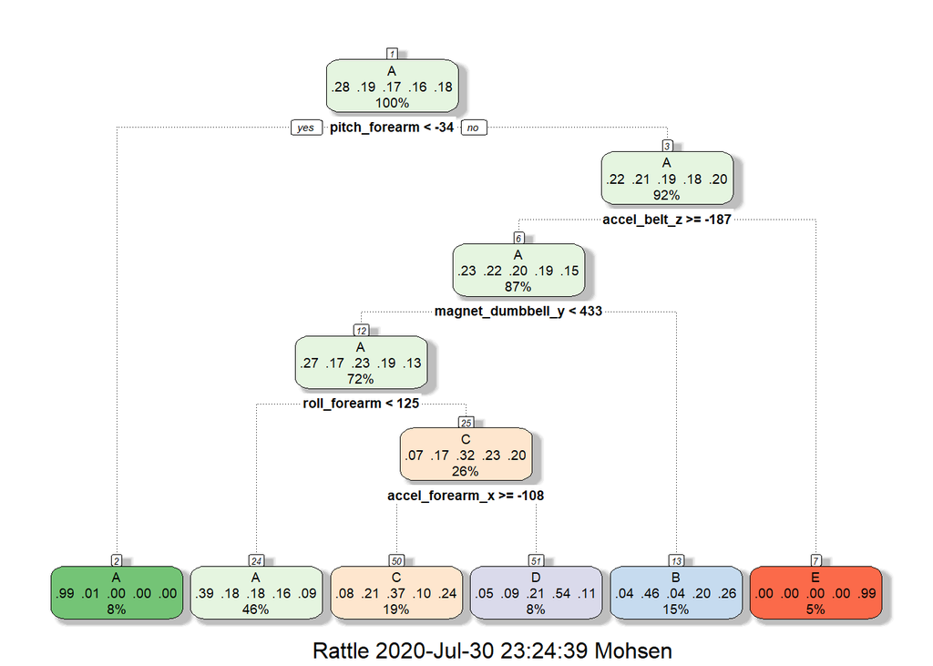

### The Random Forest Model

Confusion Matrix and Statistics

```
      Reference
```

Prediction A B C D E A 2229 0 1 1 1 B 15 1495 3 4 1 C 0 11 1347 9 1 D 1 0 25 1256 4 E 0 1 3 3 1435

Overall Statistics

```
           Accuracy : 0.9893
             95% CI : (0.9868, 0.9915)
No Information Rate : 0.2861
P-Value [Acc > NIR] : < 2.2e-16

              Kappa : 0.9865
```

Mcnemar's Test P-Value : 0.0001679

Statistics by Class:

```
                 Class: A Class: B Class: C Class: D Class: E
```

Sensitivity 0.9929 0.9920 0.9768 0.9866 0.9951 Specificity 0.9995 0.9964 0.9968 0.9954 0.9989 Pos Pred Value 0.9987 0.9848 0.9846 0.9767 0.9951 Neg Pred Value 0.9971 0.9981 0.9951 0.9974 0.9989 Prevalence 0.2861 0.1921 0.1758 0.1622 0.1838 Detection Rate 0.2841 0.1905 0.1717 0.1601 0.1829 Detection Prevalence 0.2845 0.1935 0.1744 0.1639 0.1838 Balanced Accuracy 0.9962 0.9942 0.9868 0.9910 0.9970

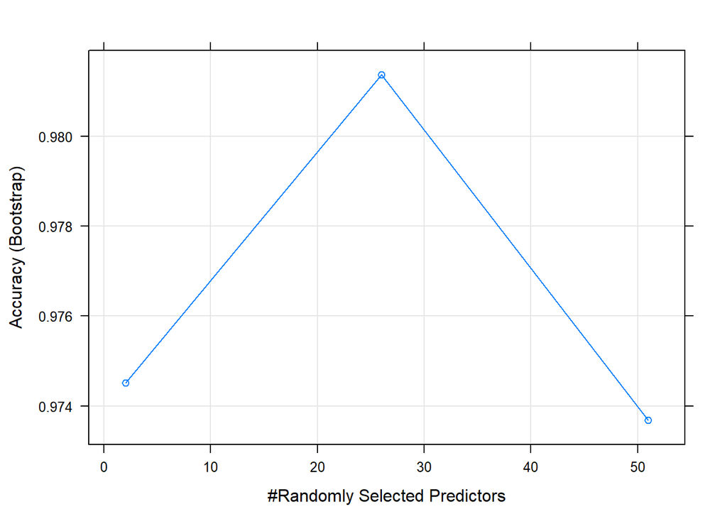